# Week11 : Group Homework - Gomaji

第15組(組員:賴怡廷、林孟慧、盧穎、陳鳯婷、郝逸清、林德昌)

### Part I – 爬蟲程式

首先用以下程式碼讀取網頁上的資訊並整理成可處理的表格資料，為方便Knit，僅第一次先讀取資料並儲存，之後再將資料載入作運用。 資料抓取時間：2016-11-24 19:06:58 CST

```r
library(rvest)
library(dplyr)
library(stringr)
library(httr)

Sys.time() # 顯示資料讀取時間
df <- data.frame()

place <- c("Yilan", "Taipei", "Hsinchu", "Taichung", "Tainan", "Kaosiung")

for(j in (1:length(place)))
{
  k <- 1
  url <- paste0("http://www.gomaji.com/index.php?city=", place[j],
                "&ref=396&gclid=Cj0KEQiAx7XBBRCdyNOw6PLHrYABEiQAJtyEQ4edEthTWJmdHtk7Bng95CAAkHaY5TAQf5yUQ2KrBdAaAg_V8P8HAQ&page=", k)

  res <- GET(url)
  resText = content(res, "text", encoding = "utf8")
  doc <- read_html(resText, encoding = "utf8")

  while(grepl("img/error404.jpg", doc) == F)
  {
    k <- k + 1
    url <- paste0("http://www.gomaji.com/index.php?city=", place[j],
                  "&ref=396&gclid=Cj0KEQiAx7XBBRCdyNOw6PLHrYABEiQAJtyEQ4edEthTWJmdHtk7Bng95CAAkHaY5TAQf5yUQ2KrBdAaAg_V8P8HAQ&page=", k)
    res <- GET(url)
    resText = content(res,"text",encoding = "utf8")
    doc <- read_html(resText, encoding = "utf8")
    page <- k-1
  }

  for(i in (1:page))
  {
    gomaji <- paste0("http://www.gomaji.com/index.php?city=", place[j], "&ch=7&page=", i)

    # 店名
    storename <- read_html(gomaji, encoding = "UTF-8") %>%
      html_nodes("#lb_deal .ref_name_2") %>%
      html_text()

    # 購買價格
    price <- read_html(gomaji, encoding = "UTF-8") %>%
      html_nodes("#lb_deal span") %>%
      html_text() %>%
      as.numeric()

    # 餐劵內容
    content <- read_html(gomaji, encoding = "UTF-8") %>%
      html_nodes(".proname_3") %>%
      html_text()

    # 餐劵連結網址
    href <- read_html(gomaji, encoding = "UTF-8") %>%
      html_nodes(xpath = "//*[@id='lb_deal']//li/a") %>%
      html_attrs() %>%
      sapply("[", 1)
    href <- paste0("http://www.gomaji.com/", href)

    # 商品原價
    preprice <- read_html(gomaji, encoding = "UTF-8") %>%
      html_nodes("#lb_deal s") %>%
      html_text() %>%
      str_replace_all("[^[:alnum:]]", "") %>%
      as.numeric()

    county <- place[j]

    df.temporary <- data.frame(storename, price, preprice, content, href, county)
    df <- rbind(df, df.temporary)
  }
}

df <- filter(df, !is.na(df$price)) %>%
  mutate(discount = round(price / preprice, digits = 2)) # 計算折扣

df$href <- as.character(df$href)

for(i in (1:length(df$storename)))
{
  if(is.na(df$storename[i])) break
  title <- read_html(df$href[i]) %>%
    html_nodes("#product h1") %>%
    html_text()
  df$title[i] <- title

  # 商品已賣數量（人/份）
  amount <- read_html(df$href[i]) %>%
    html_nodes(".amount") %>%
    html_text() %>%
    str_replace_all("[^[:alnum:]]", "") %>%
    str_split("人") %>%
    sapply("[[", 1) %>%
    str_split("份") %>%
    sapply("[[", 1) %>%
    as.numeric()
  df$amount[i] <- ifelse(length(amount) != 0, amount, 0)

  # 位於該縣市的哪個行政區
  area <- read_html(df$href[i]) %>%
    html_nodes(".area") %>%
    html_text()
  df$area[i] <- ifelse(length(area) != 0, area, NA)
}

# 為了獲取完整的店名
df$storename <- sub(".*【(.+)】.*", "\\1", df$title)

Taiwan <- df
save(Taiwan, file = "C:\\Users\\es901\\Documents\\dsR\\data\\wk11\\Taiwan.RData")
```

### Part II – 概略分析

綜合性分析各資料的狀況，期望找出影響銷售量的因素。

```r
library(rvest)
library(dplyr)
library(stringr)

load("C:\\Users\\es901\\Documents\\dsR\\data\\wk11\\Taiwan.RData")
df <- Taiwan

cat(paste0("廣告數： ", length(df$storename), " 則"), "\n",
    paste0("廣告店家數： ", length(unique(df$storename)), " 家"))
```

```
## 廣告數： 1087 則
##  廣告店家數： 712 家
```

六縣市的部份總共有1087筆資料，而資料中有店家重複的張貼商品資訊（只有712家），應該是張貼了不一樣的餐劵內容，或是店家花了比較多的錢才能重複張貼商品資訊，還有一些是多分店的店家，在選擇不同的縣市查詢時，資訊會分別顯示在搜尋結果裡。

```r
# 同一家店可張貼不同的廣告資訊，故選擇href，不同的網頁即代表不同的商品資訊
df.unique <- df[!duplicated(df$href),]
library(knitr)
kable(summary(df.unique), format = "markdown")
```

|  | storename | price | preprice | content | href | county | discount | title | amount | area |
| --- | --- | --- | --- | --- | --- | --- | --- | --- | --- | --- |
|  | Length:828 | Min. : 31.0 | Min. : 35.0 | 平假日皆可抵用100元消費金額: 36 | Length:828 | Yilan : 21 | Min. :0.3300 | Length:828 | Min. : 0.0 | Length:828 |
|  | Class :character | 1st Qu.: 188.0 | 1st Qu.: 259.8 | 平假日皆可抵用300元消費金額: 32 | Class :character | Taipei :535 | 1st Qu.:0.6575 | Class :character | 1st Qu.: 91.5 | Class :character |
|  | Mode :character | Median : 322.5 | Median : 478.0 | 平假日皆可抵用500元消費金額: 21 | Mode :character | Hsinchu : 61 | Median :0.7100 | Mode :character | Median : 314.0 | Mode :character |
|  | NA | Mean : 518.0 | Mean : 750.3 | 平假日皆可抵用200元消費金額: 17 | NA | Taichung:122 | Mean :0.7112 | NA | Mean : 2360.1 | NA |
|  | NA | 3rd Qu.: 599.0 | 3rd Qu.: 882.5 | 平假日皆可抵用250元消費金額: 12 | NA | Tainan : 89 | 3rd Qu.:0.7900 | NA | 3rd Qu.: 1281.8 | NA |
|  | NA | Max. :10888.0 | Max. :19800.0 | 平假日皆可抵用150元消費金額: 11 | NA | Kaosiung: 0 | Max. :1.0000 | NA | Max. :238380.0 | NA |
|  | NA | NA | NA | (Other) :699 | NA | NA | NA | NA | NA | NA |

```r
cat("price 標準差為", round(sd(df.unique$price), 2), "\n",
    "preprice 標準差為", round(sd(df.unique$preprice), 2), "\n",
    "amount 標準差為", round(sd(df.unique$amount), 2), "\n",
    "discount 標準差為", round(sd(df.unique$discount), 2))
```

```
## price 標準差為 711.64
##  preprice 標準差為 1163.44
##  amount 標準差為 10988.17
##  discount 標準差為 0.11
```

經整理後，實際的商品資訊是828則，表示連鎖店刊登的廣告佔比滿重的。

商品價格不管是原價還是折扣後的價格，變動範圍都滿大的，從未滿40元到逼近20000元的都有，商品的多樣性頗高（反映在價格上）。

縣市分佈在這裡討論較不適合，通常為多分店資訊時，網頁只會歸類在一個縣市裡，故在稍後作分析。

折扣的部份平均來說約落在7折左右，變動不大。

已購買數量變化區間也很大，但也有可能是因為刊登時間的不同，造成這樣的差異（大約在周末的時候有些商品會下架、新商品剛刊登）。

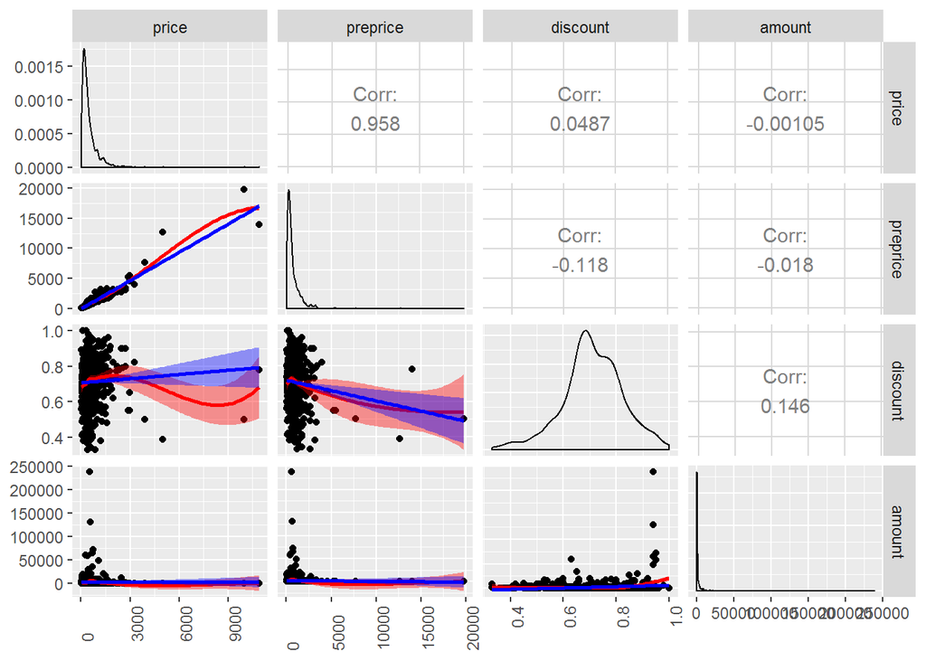

```r
library(GGally)
library(ggplot2)

my_fn <- function(data, mapping, ...)
{
  p <- ggplot(data = data, mapping = mapping) +
    geom_point() +
    theme(axis.text.x = element_text(angle = 90, hjust = 0)) +
    geom_smooth(method = loess, fill = "red", color = "red", ...) +
    geom_smooth(method = lm, fill = "blue", color = "blue", ...)
  p
}

ggpairs(df.unique, columns = c(2, 3, 7, 9), lower = list(continuous = my_fn))
```

上圖為實際購買價格（price）、原價（preprice）、購買數量（amount）、折扣（discount）四項各自的機率密度圖、回歸作圖與相關係數，藍色線為線性回歸，紅色線則為多項式回歸，搭配以上的表格，能更清楚知道各資料的分布狀況，但因為極值的影響，使得使得分佈上不好觀察。

```r
df.remove <- subset(df.unique, price < 3000 & amount < 5000)
cat("大略去掉極值後為", nrow(df.remove), "筆資料")
```

```
## 大略去掉極值後為 747 筆資料
```

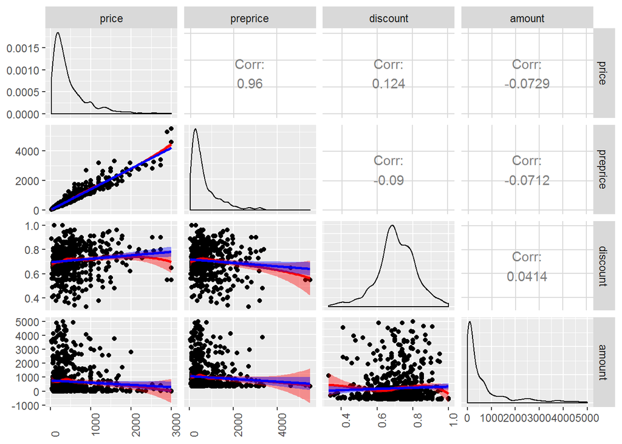

```r
ggpairs(df.remove, columns = c(2, 3, 7, 9), lower = list(continuous = my_fn))
```

```r
library(knitr)
df.arrange <- subset(df.unique, select = c(-href, -title)) %>%
  arrange(desc(amount))
kable(head(df.arrange, 10), format = "markdown")
```

| storename | price | preprice | content | county | discount | amount | area |
| --- | --- | --- | --- | --- | --- | --- | --- |
| TASTy 西堤牛排 | 538 | 570 | 全省通用餐券 | Yilan | 0.94 | 238380 | 多分店 |
| 陶板屋和風創作料理 | 587 | 625 | 全省通用餐券 | Yilan | 0.94 | 130148 | 多分店 |
| 藝奇新日本料理 | 726 | 768 | 全省通用餐券 | Yilan | 0.95 | 72540 | 多分店 |
| 原燒 優質原味燒肉 | 705 | 748 | 全省通用餐券 | Yilan | 0.94 | 64736 | 多分店 |
| 角子虎北方水餃館 | 299 | 475 | 精選分享餐 | Taipei | 0.63 | 59754 | 9家分店 |
| 舒果 新米蘭蔬食 | 416 | 438 | 全省通用餐券 | Taipei | 0.95 | 58196 | 多分店 |
| 夏慕尼 新香榭板燒 | 1060 | 1133 | 全省通用餐券 | Yilan | 0.94 | 48806 | 多分店 |
| 美麗信花園酒店 | 699 | 1078 | 冬季鍋物百匯-五星頂級吃到飽 | Taipei | 0.65 | 34608 | 中山區 |
| 首都大飯店(首都牛排館) | 435 | 495 | 假日下午茶宮廷沙拉吧單人吃到飽 | Taipei | 0.88 | 29166 | 中山區 |
| 首都大飯店(首都牛排館) | 450 | 528 | 美國美食節-Semi Buffet單人吃到飽 A.平日午餐 / B.平日晚餐/假日午餐/假日晚餐 | Taipei | 0.85 | 26616 | 中山區 |

為檢視分店性質與購買數量之間的關係，選取購買量在10000以上的資料。

```r
library(gridExtra)
df.arrange <- df.arrange %>%
  mutate(more = ifelse(grepl("分店", area), 1, 0))
  # 若為多分店的團購資訊，則為1，則為0

df.arrange$county <- as.character(df.arrange$county)
df.large <- df.arrange %>%
  filter(amount >= 10000) %>%
  mutate(type = ifelse(more != 0, "多分店", county)) %>%
  group_by(type) %>%
  summarise(count = n(), avg.amount = mean(amount))

kable(df.large, format = "markdown")
```

| type | count | avg.amount |
| --- | --- | --- |
| Tainan | 1 | 10347.00 |
| Taipei | 17 | 18421.18 |
| Yilan | 2 | 12987.50 |
| 多分店 | 14 | 55361.07 |

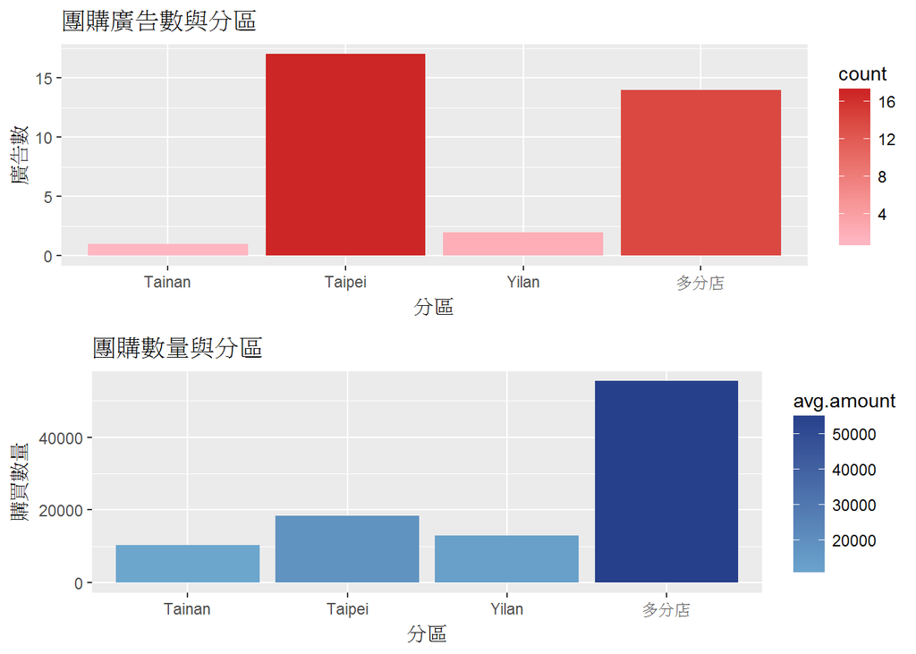

```r
p1 <- ggplot(df.large, aes(x = type, y = count, fill = count)) +
  geom_bar(stat = "identity") +
  labs(title = "團購廣告數與分區", x = "分區", y = "廣告數") +
  scale_fill_continuous(low = "lightpink", high = "firebrick3",
                        guide = "colorbar")
p2 <- ggplot(df.large, aes(x = type, y = avg.amount, fill = avg.amount)) +
  geom_bar(stat = "identity") +
  labs(title = "團購數量與分區", x = "分區", y = "購買數量") +
  scale_fill_continuous(low = "skyblue3", high = "royalblue4",
                        guide = "colorbar")
grid.arrange(p1, p2, nrow = 2)
```

購買量大於10000的資料為34筆，其中多分店的全國連鎖佔了14筆，僅次於臺北的17筆，但就購買數量而言，多分店為50000，明顯高於其他地區的單店銷售量（皆位於20000以下），與前面的推論相呼應。

### Part III – 地理分區與商品

```r
library(spdep)
library(maptools)
library(sp)
library(rgeos)

tw.map <- readShapeSpatial("C:\\Users\\es901\\Documents\\dsR\\data\\Town_MOI_1041215.shp")
countytaiwan<- unionSpatialPolygons(tw.map, tw.map$C_Name)

df.num <- df %>%
  mutate(more = ifelse(grepl("分店", area), 1, 0)) %>%
  group_by(county) %>%
  summarise(count = n(), avg.price = round(mean(price)),
            avg.discount = round(mean(discount), 2),
            avg.amount = round(mean(amount)), more = sum(more)) %>%
  mutate(fraction = (more/count)*100) # 多分店廣告資訊佔該分區的比例
```

先以表格資料作初步檢視

```r
kable(df.num, format = "markdown")
```

| county | count | avg.price | avg.discount | avg.amount | more | fraction |
| --- | --- | --- | --- | --- | --- | --- |
| Yilan | 21 | 593 | 0.88 | 29765 | 9 | 42.85714 |
| Taipei | 556 | 579 | 0.70 | 3189 | 57 | 10.25180 |
| Hsinchu | 99 | 434 | 0.78 | 7713 | 35 | 35.35354 |
| Taichung | 165 | 443 | 0.76 | 4845 | 38 | 23.03030 |
| Tainan | 120 | 320 | 0.74 | 6106 | 31 | 25.83333 |
| Kaosiung | 126 | 842 | 0.70 | 3106 | 13 | 10.31746 |

```r
taiwan.map <- fortify(countytaiwan)
df.data <- rbind(df.num, df.num[2,]) %>%
  rbind(df.num[3,])
# Gomaji的資料呈現將新北市、臺北市合在一起，新竹市、新竹縣合在一起故作圖時一起表示
include.county <- c("宜蘭縣", "臺北市", "新竹市", "臺中市", "臺南市", "高雄市",
                    "新北市", "新竹縣")
df.data$id <- include.county
a <- unique(taiwan.map$id)
df.id <- data.frame(id = a)
taiwan.data <- merge(df.id, df.data, by = "id", all = T)

c1 <- gCentroid(countytaiwan, byid = T)
label.set <- data.frame(id = names(c1@coords[, 1]),
                        long = c1@coords[, 1], lat = c1@coords[, 2])
label.set$id <- as.character(label.set$id)

label.data <- label.set
label.data$id <- if_else(label.data$id %in% include.county, label.set$id, "") %>%
  str_replace_all("宜蘭縣", "宜蘭") %>%
  str_replace_all("臺北市", "臺北") %>%
  str_replace_all("臺中市", "臺中") %>%
  str_replace_all("臺南市", "臺南") %>%
  str_replace_all("高雄市", "高雄") %>%
  str_replace_all("新竹縣", "新竹") %>%
  str_replace_all("新北市", "") %>%
  str_replace_all("新竹市", "")
```

將地理分區資料結合從台灣政府公開資料平台下載的 shapefile 作圖

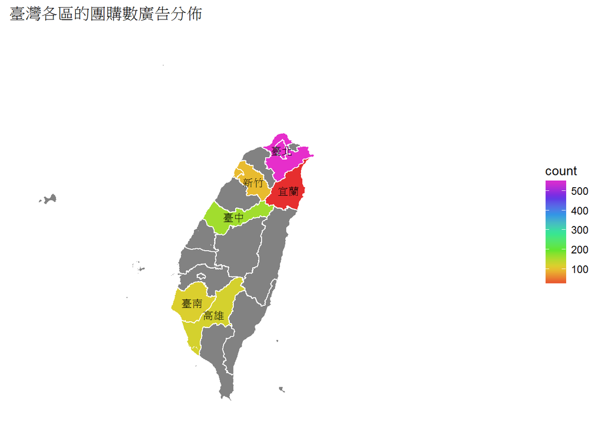

```r
ggplot(taiwan.data, aes(map_id = id)) +
  geom_map(aes(fill = count), map = taiwan.map, color = "white") +
  expand_limits(x = taiwan.map$long, y = taiwan.map$lat) +
  geom_text(data = label.data, aes(x = long, y = lat, label = id), size = 3) +
  scale_fill_gradientn(colours = rainbow(7, s = 0.8, v = 0.9, alpha = 1),
                       guide = "colourbar", na.value = "gray51") +
  ggtitle("臺灣各區的團購數廣告分佈") +
  theme(panel.grid = element_blank(), panel.background = element_blank(),
        axis.text = element_blank(), axis.ticks = element_blank(),
        axis.title = element_blank())
```

這六個區域的廣告數大致與該區經濟發展程度呈正相關，而其中台北廣告數甚至比其他五區高了許多，廣告數對低的則落於宜蘭。

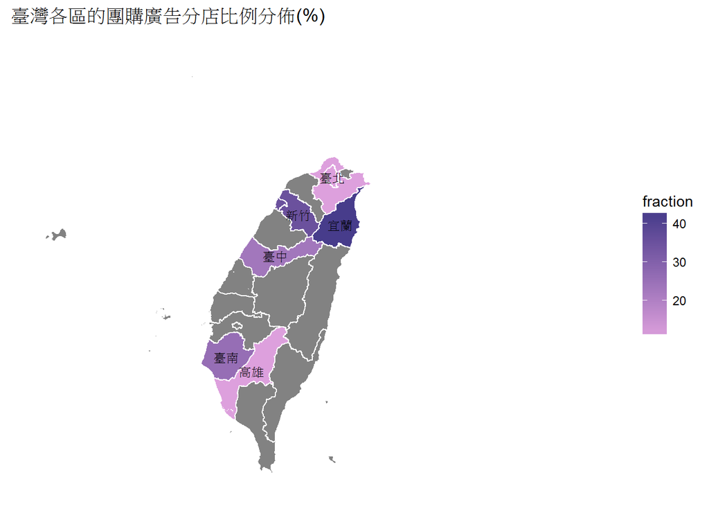

```r
ggplot(taiwan.data, aes(map_id = id)) +
  geom_map(aes(fill = fraction), map = taiwan.map, color = "white") +
  geom_text(data = label.data, aes(x = long, y = lat, label = id), size = 3) +
  expand_limits(x = taiwan.map$long, y = taiwan.map$lat) +
  scale_fill_continuous(low = "plum", high = "slateblue4",
                        guide = "colorbar", na.value = "gray51") +
  ggtitle("臺灣各區的團購廣告分店比例分佈(%)") +
  theme(panel.grid = element_blank(), panel.background = element_blank(),
        axis.text = element_blank(), axis.ticks = element_blank(),
        axis.title = element_blank())
```

分店廣告比例最高的落在宜蘭，表示多數的刊登店家為全國連鎖店，比例最低的為台北與高雄，應是該區的特色店家較多（單店廣告比例較高）。

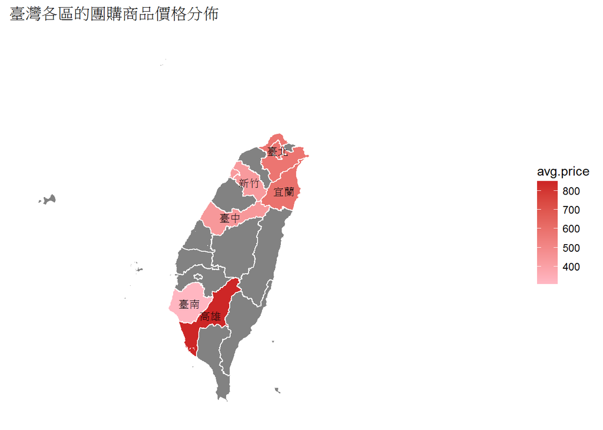

```r
ggplot(taiwan.data, aes(map_id = id)) +
  geom_map(aes(fill = avg.price), map = taiwan.map, color = "white") +
  geom_text(data = label.data, aes(x = long, y = lat, label = id), size = 3) +
  expand_limits(x = taiwan.map$long, y = taiwan.map$lat) +
  scale_fill_continuous(low = "lightpink", high = "firebrick3",
                        guide = "colorbar", na.value = "gray51") +
  ggtitle("臺灣各區的團購商品價格分佈") +
  theme(panel.grid = element_blank(), panel.background = element_blank(),
        axis.text = element_blank(), axis.ticks = element_blank(),
        axis.title = element_blank())
```

原本預測團購商品價格最高的地區會是台北，結果是高雄，可能跟高雄地區刊登團購網廣告的商品多為單位價格高之種類有關(也許是當地販售較低單位價格商品的小店比較不願意投入成本在團購廣告中)。而台南當地飲食消費偏低，所以團購商品價格若高，便無法取得銷售優勢。其餘四個地區的商品價格分布都算平均。

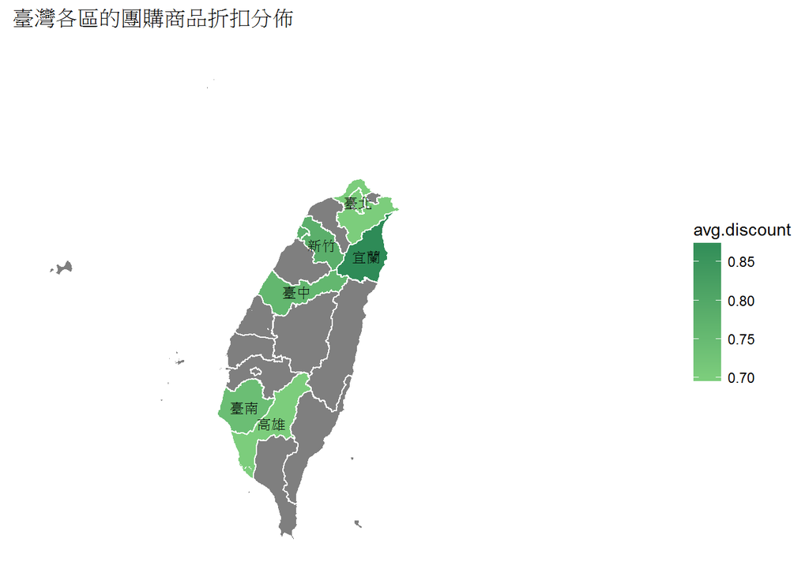

```r
ggplot(taiwan.data, aes(map_id = id)) +
  geom_map(aes(fill = avg.discount), map = taiwan.map, color = "white") +
  geom_text(data = label.data, aes(x = long, y = lat, label = id), size = 3) +
  expand_limits(x = taiwan.map$long, y = taiwan.map$lat) +
  scale_fill_continuous(low = "palegreen3", high = "seagreen4",
                        guide = "colorbar") +
  ggtitle("臺灣各區的團購商品折扣分佈") +
  theme(panel.grid = element_blank(), panel.background = element_blank(),
        axis.text = element_blank(), axis.ticks = element_blank(),
        axis.title = element_blank())
```

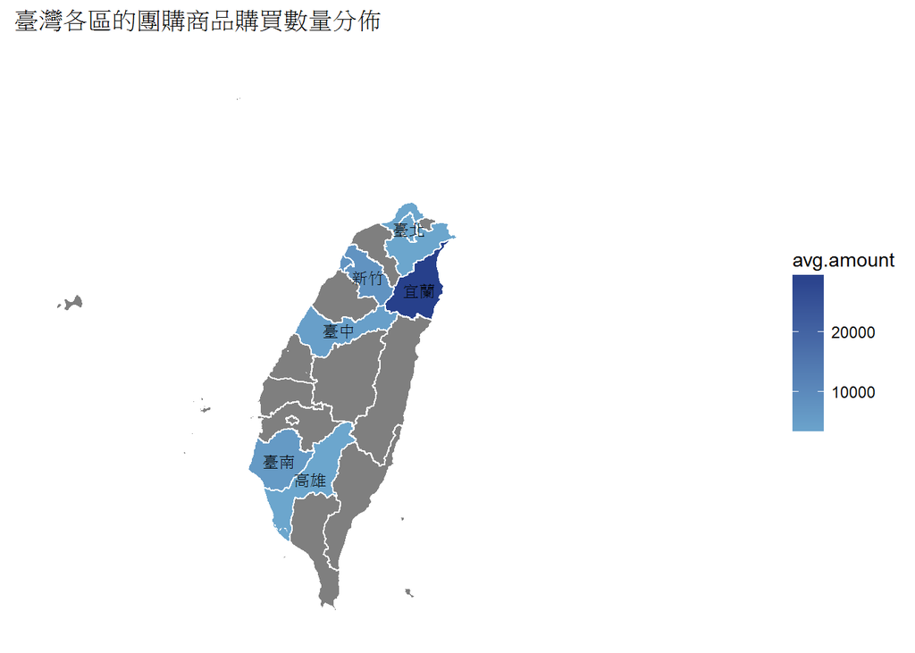

```r
ggplot(taiwan.data, aes(map_id = id)) +
  geom_map(aes(fill = avg.amount), map = taiwan.map, color = "white") +
  geom_text(data = label.data, aes(x = long, y = lat, label = id), size = 3) +
  expand_limits(x = taiwan.map$long, y = taiwan.map$lat) +
  scale_fill_continuous(low = "skyblue3", high = "royalblue4",
                        guide = "colorbar") +
  ggtitle("臺灣各區的團購商品購買數量分佈") +
  theme(panel.grid = element_blank(), panel.background = element_blank(),
        axis.text = element_blank(), axis.ticks = element_blank(),
        axis.title = element_blank())
```

此圖分布與上圖大致相同，因此上述推測若正確，那麼這個行銷策略是可行的，因為我們可以明顯看出宜蘭地區商品購買數量較其他地區高出許多（大部份的數據來自全國連鎖店）；高雄和台北的分店比例最少，購買數量相對較少，跟數據計算的方式有關。

P.S.計算時，若為多分店資訊，而在各縣市都有資料時，各縣市會重複計算（因為不能確定所有分店在各縣市的分佈與購買人的分布情形）。

### Data Source :

- [Gomaji 最大吃喝玩樂劵平台](http://www.gomaji.com/Tainan)
- [台灣政府公開資料平台](http://data.gov.tw/node/7441)